# Exercise 4 - `git` it done

Gerko Vink

Markup Languages and Reproducible Programming in Statistics

Dear all,

This week we will learn how to use $git$ properly when we mess up. But let’s not learn that on this year’s repo ;-). Fork the last year’s repository [here](https://github.com/gerkovink/markup2020), deselect! `Copy the master branch only` in order to copy all branches and checkout the `Exercise_wk4` branch.

Let’s start.

Gerko

# 1 Disclaimer

I’ll take you by the hand through the exercise. So if you follow this manual step by step, you’ll be done at the end and you will have a good notion of troubleshooting with `git` [or a reference thereof].

This exercise is a summary of important commands. A full and comprehensive overview can be found in [the `pro git` book](https://git-scm.com/book/en/v2).

O, and I forgot to tell you: you’ll need the terminal for this exercise. You may use the one in `RStudio`, or the dedicated terminal on UNIX systems or the command prompt or [Windows Terminal](https://www.microsoft.com/en-us/p/windows-terminal/9n0dx20hk701?activetab=pivot:overviewtab) on Windows.

# 2 Prepare

Before we continue it is good to all start from the point of departure.

1. Use the terminal to navigate to the `git` repository (the location of the git repo on your HDD)
2. Type `git pull` to make sure that you obtain the latest state from the remote on `GitHub`

```
% git pull
Already up to date.
```

Don’t type the `%`; that is just the command prompt indicator on my machine. Yours may be different, such as `>` or `$`. We see that `git` reminds me that I already have the latest state. I am up to date.

3. Change the branch to the `Exercise_wk4` branch.

```
% git checkout Exercise_wk4
Switched to branch 'Exercise_wk4'
Your branch is up to date with 'origin/Exercise_wk4'.
```

I’ve now been switched to the `Exercise_wk4` branch. It is up to date with `origin/Exercise_wk4`, meaning that GitHub and my local copy are in sync. `origin` is a shorthand name for the remote repository that a project was originally cloned from. It is useful that `origin` is referenced instead of the original repo’s URL –> This makes referencing much more convenient.

# 3 Inspect the current state

Make sure you are in the `Exercise_wk4` branch. Then Use `git log --graph` to inspect the current Git branch and its commits.

```
% git log --graph
*   commit 176137b1667cc6903f7a9eead5723892ef1a77a7 (HEAD -> master, origin/master, origin/HEAD)
|\  Merge: 0e67723 c902093
| | Author: Gerko Vink <g.vink@uu.nl>
| | Date:   Thu Oct 29 12:44:01 2020 +0100
| |
| |     Merge pull request #38 from thomasjwise/wisedev
| |
| |     Assignment 3 - Beamer PDF
| |
| |     Well done ✅
| |
| * commit c9020931678d90d91cfe21778e6ce5b4943e46cb
| | Author: Thomas Wise <48682160+thomasjwise@users.noreply.github.com>
| | Date:   Wed Oct 28 13:59:23 2020 +0100
| |
| |     Assignment 3 - Beamer PDF
| |
* |   commit 0e67723572744b769389f5b8883c9f1aa6a3b7dd
|\ \  Merge: 4134b75 1f488c6
| | | Author: Gerko Vink <g.vink@uu.nl>
| | | Date:   Thu Oct 29 11:27:16 2020 +0100
| | |
```

We see information about the history that brought us to this point in time. We see commit messages, the author, the dates, the SHA-1 hash and the graph tree. We asked for the graph tree with `--graph`.

You can scroll up and down the graph. To exit the graph window, type `q`. For help, type `h`. To obtain a more condensed graph, use

```
% git log --oneline --graph
*   176137b (HEAD -> Exercise_wk4, origin/master, origin/HEAD, origin/Exercise_wk4, master) Merge pull request #38 from thomasjwise/wisedev
|\
| * c902093 Assignment 3 - Beamer PDF
* |   0e67723 Merge pull request #39 from gerkovink/SofieIssue
|\ \
| * | 1f488c6 (SofieIssue) remove pipe operator
| * | 4ead406 update readme.md
|/ /
* |   4134b75 Merge pull request #37 from pietjonker/piet
|\ \
| * | f50014b commit assignment 2
| * | 5ae2b9b Assignment 1 and 2
* | |   f277a35 Merge pull request #35 from zoedunias/zoedev
|\ \ \
| * | | 1c9aad6 Added Exercise 2
* | | |   43fb1ed Merge pull request #34 from RianneKraakman/riannedev
|\ \ \ \
| * | | | 75d9293 Add assignment 2
* | | | |   d3df110 Merge pull request #33 from gerkovink/gerkodev
|\ \ \ \ \
| * \ \ \ \   34954f8 (origin/gerkodev, gerkodev) Merge pull request #22 from Goorbergh/ruben_assignment_1
```

This graph view is much more condensed. The nice thing about this view is the direct depiction of each action’s abbreviated SHA-1 key.

We can use the SHA-1 keys to instruct `git`. For example, to obtain the history on commit `c902093`, we only need to refer the SHA-1 hash.

```
% git log c902093
commit c9020931678d90d91cfe21778e6ce5b4943e46cb
Author: Thomas Wise <48682160+thomasjwise@users.noreply.github.com>
Date:   Wed Oct 28 13:59:23 2020 +0100

    Assignment 3 - Beamer PDF

commit db649539738bb30b63d93053b67891ef6c55037e
Author: Thomas Wise <48682160+thomasjwise@users.noreply.github.com>
Date:   Wed Sep 16 14:04:21 2020 +0200

    Assignment 1

commit 21a3b5ac1535703f4ce0d6feb2ccf3703f95eee3
Merge: 7f0806b f4a11cb
Author: Gerko Vink <g.vink@uu.nl>
Date:   Tue Sep 15 20:15:25 2020 +0200

    Merge pull request #2 from gerkovink/gerkodev

    This image is too large

commit f4a11cbed729bc8454c01866aab4291b3b580d6f
Author: Gerko Vink <g.vink@uu.nl>
```

Or, a more condensed version of the same

```
% git log c902093 --pretty=oneline
c9020931678d90d91cfe21778e6ce5b4943e46cb Assignment 3 - Beamer PDF
db649539738bb30b63d93053b67891ef6c55037e Assignment 1
21a3b5ac1535703f4ce0d6feb2ccf3703f95eee3 Merge pull request #2 from gerkovink/gerkodev
f4a11cbed729bc8454c01866aab4291b3b580d6f resize image
7f0806b68387d4f3c8af5c1f27d94b69e90a2d13 Merge pull request #1 from gerkovink/gerkodev
a36ed81b3831e6084c2adf661dc4cfb32c4cb5f7 add childhood memory
9ba9c43437a7f00f5095df55db0c07d7233ad152 Add CV
9bf1c32ea55b60bce613d65765c18deb522772ff Update .gitignore
18761716665262f19296fb5d8e7c1720c8cea58a Merge branch 'master' of https://github.com/gerkovink/markup2020
1ee60aa26142b5f175928d409614b8de84c1ef79 Update .gitignore
7c3d816264b5629e7bfe112954178648d94a37b4 Delete markup_sticker_SMALL.psd
37c356ca51b4ed03e96570934f28caf5fcfd75d8 Delete .DS_Store
d56dd90172d1106117d53102e5053165bc182020 Update .gitignore
e7b78b592a8000d3a647de3a265c69496adebfe5 Update .gitignore
fdd923ad2b522d6e4357229ea801d23ec5b16717 update readme
7e14559d7f7e8676d557c9b73fc43fb3a66a0c3c added sticker
493609efa7ce659ebebf5a0d0300f23788397e68 Initial commit
```

Please note that we only reference the short hash. There is no need to reference the longer hash as long as the sequence of the shorter reference is unique.

From this `--pretty=oneline` view it is now easy to spot the origin of our course repository - the initial commit that initiated the `git` goodness. You can also see that I updated the `.gitignore`, a hidden file that specifies which files and directories to be ignored by `git`. And I did some cosmetic changes and file deletions. This is very insightfull because of the detailed, but consice commit messages.

# 4 Checkout an old state

Go back in time to `21a3b5ac1535703f4ce0d6feb2ccf3703f95eee3 Merge pull request #2 from gerkovink/gerkodev`.

To do so, we only need to refer the start of the SHA-1 key.

```
% git checkout 21a3b5a
Note: switching to '21a3b5a'.

You are in 'detached HEAD' state. You can look around, make experimental
changes and commit them, and you can discard any commits you make in this
state without impacting any branches by switching back to a branch.

If you want to create a new branch to retain commits you create, you may
do so (now or later) by using -c with the switch command. Example:

  git switch -c <new-branch-name>

Or undo this operation with:

  git switch -

Turn off this advice by setting config variable advice.detachedHead to false

HEAD is now at 21a3b5a Merge pull request #2 from gerkovink/gerkodev
```

We are now at the old state. So we went back in time. The current state where we are is independent from all later commits, but is built exactly on all preceding commits as per the tree.

There are a couple of terms that are *new*:

- HEAD: *The HEAD in `git` is the pointer to the current branch reference. It is the last commit you have made or checked out [in our case].* **REMEMBER that the head will always serve as the parent to the next commit**
- detached HEAD: *The same as the head, but now the pointer references a specific commit and not a branch.*

## 4.1 The problem with a detached HEAD

[This webpage](https://www.git-tower.com/learn/git/faq/detached-head-when-checkout-commit/) illustrates the dangers of committing changes under a detached head quite nicely:

> The HEAD pointer in `git` determines your current working revision (and thereby the files that are placed in your project’s working directory). Normally, when checking out a proper branch name, Git automatically moves the HEAD pointer along when you create a new commit. You are automatically on the newest commit of the chosen branch.  
> When you instead choose to check out a commit hash, `git` won’t do this for you. The consequence is that when you make changes and commit them, these changes do NOT belong to any branch. This means they can easily get lost once you check out a different revision or branch: not being recorded in the context of a branch, you lack the possibility to access that state easily (unless you have a brilliant memory and can remember the commit hash of that new commit…).

The useful thing about going to an old commit is that you can take this state as a point of departure. Just beware of the pitfalls of working under a detached HEAD.

## 4.2 leave the detached HEAD

Go back to the branch HEAD

```
% git switch -
Previous HEAD position was 21a3b5a Merge pull request #2 from gerkovink/gerkodev
Switched to branch 'Exercise_wk4'
Your branch is up to date with 'origin/Exercise_wk4'.
```

# 5 Make a new branch of the old state

Let’s take that old state and make it into a proper point of departure for new things. Again, reference `21a3b5ac1535703f4ce0d6feb2ccf3703f95eee3 Merge pull request #2 from gerkovink/gerkodev`, but now we make the state of `21a3b5a` into a new branch. We call that branch `Wk4_markup`:

```
% git checkout -b Wk4_markup 21a3b5a
Switched to a new branch 'Wk4_markup'
```

We now have checked out an old state and made it into a new branch. The cool thing is that we can now commit all we want and everything will be properly logged. Just remember that if you’d like to go back in time and play around with an old state of your project –> **Merge the old state into a new branch** like I demonstrated above.

# 6 Add a new commit

We start by creating an empty text file

```
% touch add_text_file.txt
```

If the `touch` command does not work on your machine, you may also create this file by hand.

Now, if we would like to commit the addition of this file to our repo, we get the following:

```
% git commit -a -m 'add text file'
On branch Wk4_markup
Untracked files:
    add_text_file.txt

nothing added to commit but untracked files present
```

The commit was not succesfull, because the file `add_text_file.txt` is not yet tracked. Note that I use `-a` to specify to commit **all** changed files and folders that are tracked. I use `-m` to indicate that I would like to add the message `add text file`.

You see that using a GUI to `git` like GitHub desktop or RStudio is quite convenient if you would not like to indicate which files to track. It is also less flexible.

## 6.1 Add files to tracking

To track all untracked files and folders

```
git add -A
```

## 6.2 commit with a message

Now if we revisit the commit command

```
% git commit -a -m 'add text file'
[Wk4_markup 8d30c46] add text file
 1 file changed, 0 insertions(+), 0 deletions(-)
 create mode 100644 add_text_file.txt
```

# 7 Study the log again

```
% git log --pretty=oneline
8d30c4698b9761d650de2f5288389257762753ce (HEAD -> Wk4_markup) add text file
21a3b5ac1535703f4ce0d6feb2ccf3703f95eee3 (old-state) Merge pull request #2 from gerkovink/gerkodev
f4a11cbed729bc8454c01866aab4291b3b580d6f resize image
7f0806b68387d4f3c8af5c1f27d94b69e90a2d13 Merge pull request #1 from gerkovink/gerkodev
a36ed81b3831e6084c2adf661dc4cfb32c4cb5f7 add childhood memory
9ba9c43437a7f00f5095df55db0c07d7233ad152 Add CV
9bf1c32ea55b60bce613d65765c18deb522772ff Update .gitignore
18761716665262f19296fb5d8e7c1720c8cea58a Merge branch 'master' of https://github.com/gerkovink/markup2020
1ee60aa26142b5f175928d409614b8de84c1ef79 Update .gitignore
7c3d816264b5629e7bfe112954178648d94a37b4 Delete markup_sticker_SMALL.psd
37c356ca51b4ed03e96570934f28caf5fcfd75d8 Delete .DS_Store
d56dd90172d1106117d53102e5053165bc182020 Update .gitignore
e7b78b592a8000d3a647de3a265c69496adebfe5 Update .gitignore
fdd923ad2b522d6e4357229ea801d23ec5b16717 update readme
7e14559d7f7e8676d557c9b73fc43fb3a66a0c3c added sticker
493609efa7ce659ebebf5a0d0300f23788397e68 Initial commit
```

We can see that the HEAD is now at the latest commit and that this commit comes after the old-state from which we created the branch.

## 7.1 Now add another empty text file.

```
% touch add_another_text_file.txt
```

Let’s say that we rather would have included this file in the previous commit, we can achieve this by

[output not shown]

We have effectively ammended the previous commit. We’ve also changed the commit message into `add two text files`:

```
% git log --pretty=oneline
9e6c38c2288f7e7fce75de3bd1ffb522de112a8b (HEAD -> Wk4_markup) add two text files
21a3b5ac1535703f4ce0d6feb2ccf3703f95eee3 (old-state) Merge pull request #2 from gerkovink/gerkodev
f4a11cbed729bc8454c01866aab4291b3b580d6f resize image
7f0806b68387d4f3c8af5c1f27d94b69e90a2d13 Merge pull request #1 from gerkovink/gerkodev
a36ed81b3831e6084c2adf661dc4cfb32c4cb5f7 add childhood memory
9ba9c43437a7f00f5095df55db0c07d7233ad152 Add CV
9bf1c32ea55b60bce613d65765c18deb522772ff Update .gitignore
18761716665262f19296fb5d8e7c1720c8cea58a Merge branch 'master' of https://github.com/gerkovink/markup2020
1ee60aa26142b5f175928d409614b8de84c1ef79 Update .gitignore
7c3d816264b5629e7bfe112954178648d94a37b4 Delete markup_sticker_SMALL.psd
37c356ca51b4ed03e96570934f28caf5fcfd75d8 Delete .DS_Store
d56dd90172d1106117d53102e5053165bc182020 Update .gitignore
e7b78b592a8000d3a647de3a265c69496adebfe5 Update .gitignore
fdd923ad2b522d6e4357229ea801d23ec5b16717 update readme
7e14559d7f7e8676d557c9b73fc43fb3a66a0c3c added sticker
493609efa7ce659ebebf5a0d0300f23788397e68 Initial commit
```

# 8 Undo a commit

When shit hits the fan, we can always undo a commit. For example, the following command reverts all changes to the inital commit

```
% git reset --hard 493609e
HEAD is now at 493609e Initial commit
```

We are now back at the first commit in the project.

# 9 Undo undoing a commit

To properly do this without making mistakes, it is best to study the history of the HEAD

```
% git reflog
493609e (HEAD -> Wk4_markup) HEAD@{0}: reset: moving to 493609e
9e6c38c HEAD@{1}: commit (amend): add two text files
8d30c46 HEAD@{2}: commit: add text file
21a3b5a (old-state) HEAD@{3}: checkout: moving from Exercise_wk4 to Wk4_markup
176137b (origin/master, origin/HEAD, origin/Exercise_wk4, master, Exercise_wk4) HEAD@{4}: checkout: moving from Exercise_wk4 to Exercise_wk4
176137b (origin/master, origin/HEAD, origin/Exercise_wk4, master, Exercise_wk4) HEAD@{5}: checkout: moving from old-state to Exercise_wk4
21a3b5a (old-state) HEAD@{6}: checkout: moving from Exercise_wk4 to old-state
176137b (origin/master, origin/HEAD, origin/Exercise_wk4, master, Exercise_wk4) HEAD@{7}: checkout: moving from 21a3b5ac1535703f4ce0d6feb2ccf3703f95eee3 to Exercise_wk4
21a3b5a (old-state) HEAD@{8}: checkout: moving from Exercise_wk4 to 21a3b5a
176137b (origin/master, origin/HEAD, origin/Exercise_wk4, master, Exercise_wk4) HEAD@{9}: checkout: moving from 21a3b5ac1535703f4ce0d6feb2ccf3703f95eee3 to Exercise_wk4
21a3b5a (old-state) HEAD@{10}: checkout: moving from Exercise_wk4 to 21a3b
176137b (origin/master, origin/HEAD, origin/Exercise_wk4, master, Exercise_wk4) HEAD@{11}: checkout: moving from 21a3b5ac1535703f4ce0d6feb2ccf3703f95eee3 to Exercise_wk4
21a3b5a (old-state) HEAD@{12}: checkout: moving from Exercise_wk4 to 21a3b5a
176137b (origin/master, origin/HEAD, origin/Exercise_wk4, master, Exercise_wk4) HEAD@{13}: checkout: moving from master to Exercise_wk4
176137b (origin/master, origin/HEAD, origin/Exercise_wk4, master, Exercise_wk4) HEAD@{14}: checkout: moving from Exercise_wk4 to master
176137b (origin/master, origin/HEAD, origin/Exercise_wk4, master, Exercise_wk4) HEAD@{15}: checkout: moving from Exercise_wk4 to Exercise_wk4
176137b (origin/master, origin/HEAD, origin/Exercise_wk4, master, Exercise_wk4) HEAD@{16}: checkout: moving from master to Exercise_wk4
176137b (origin/master, origin/HEAD, origin/Exercise_wk4, master, Exercise_wk4) HEAD@{17}: checkout: moving from SofieIssue to master
1f488c6 (SofieIssue) HEAD@{18}: commit: remove pipe operator
4ead406 HEAD@{19}: commit: update readme.md
```

We are now looking at the reflog - the log of where the HEAD has been. It used to be at

```
9e6c38c HEAD@{1}: commit (amend): add two text files
```

but is now at

```
493609e (HEAD -> Wk4_markup) HEAD@{0}: reset: moving to 493609e
```

We can use this history of where the head has been to go back to the previous step. In other words, if we would like to undo a commit, we can always go back to the previous HEAD stage –> the HEAD has been moved one step forward by the commit. Likewise, if we would like to undo a hard reset, we can also go back to the previous HEAD stage –> the HEAD has been moved one step forward by the reset.

To undo it all, we can use the indicator that is referenced by the `reflog`:

```
% git reset --hard HEAD@{1}
HEAD is now at 9e6c38c add two text files
```

Using `reflog` and HEAD is in this case more flexible than using `log` and the SHA-1 hash. `reflog` yields the log of all changes in the pointer HEAD, while `log` only gives you the history of the logged commits. Once a commit is undone, it is gone from the `log`. Moreover, using `reflog` and HEAD allows you to go back into the future, like in the above example.

**NOTE: Do not wait too long to undo your resets. After a few days/weeks garbage collection may kick in and `git` will eventually see old commit as unreferenced. This makes them irretrievable**

# 10 Redo a commit

A hard reset brings you back to a previous state. It loses all changes that have been committed since. If you’d like to undo a single commit and erase the commit message, but not throw out the modifications:

```
git reset --soft 493609e
```

We are now back at the initial commit, but all changes since have been staged. We can commit these changes as

[output not shown]

If we study the log, we find that there are now only two commits.

```
% git log --pretty=oneline
5fe2c1bd44b1dbc92172b85dec3d87ced7073deb (HEAD -> Wk4_markup) everything in a single commit
493609efa7ce659ebebf5a0d0300f23788397e68 Initial commit
```

# 11 Merging branches

Let’s see if we can merge the `Wk4_markup` branch into the `Exercise_wk4` branch.

First we need to checkout the branch we would like to merge into:

```
% git checkout Exercise_wk4
Updating files: 100% (174/174), done.
Switched to branch 'Exercise_wk4'
Your branch is up to date with 'origin/Exercise_wk4'.
```

Then we can attempt to merge:

```
% git merge Wk4_markup
Auto-merging README.md
CONFLICT (content): Merge conflict in README.md
CONFLICT (add/add): Merge conflict in README.Rmd
Auto-merging README.Rmd
Automatic merge failed; fix conflicts and then commit the result.
```

We’ve now effectively created a conflict. A conflict must be resolved before a merge is possible. If you switch to GiHub desktop, you’ll see this pop-up

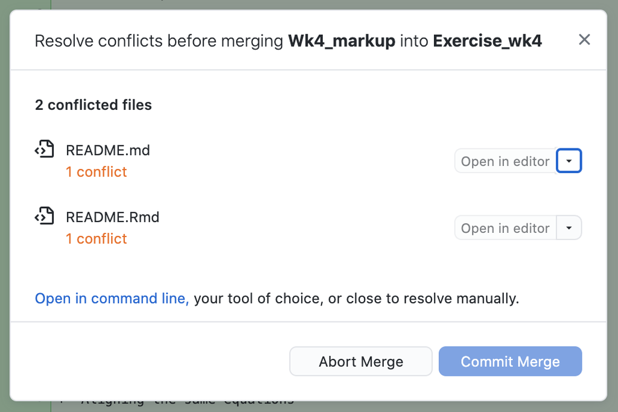

You can use the drop-down menu to choose either modified file version as the one to keep after merging (which means you’ll throw out the other version from the other branch)

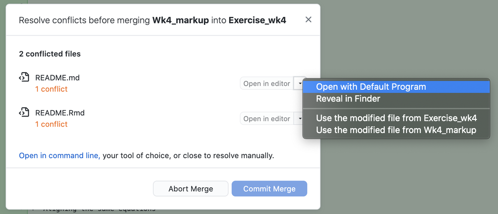

There is also the option to open the file in the editor and manually resolve the conflict.

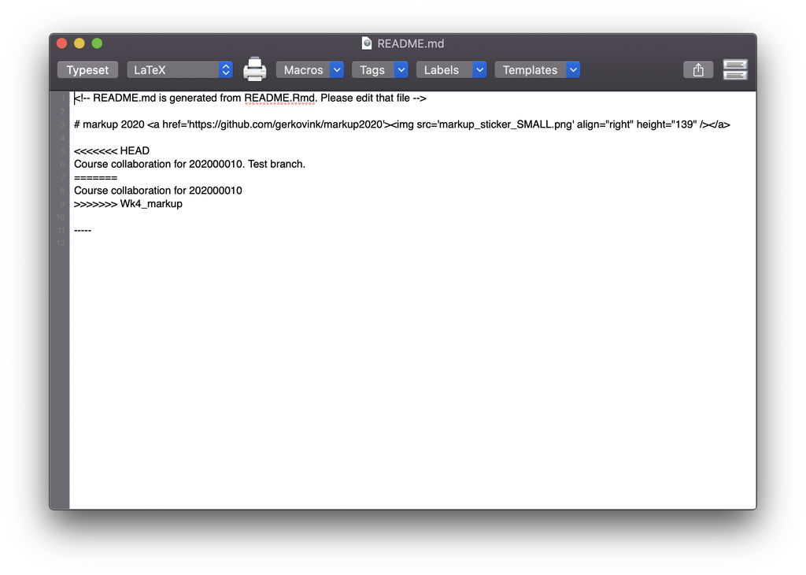

We now see the detail about this conflict. Remember that we took an old state as our point of departure? After that point I have changed the header of the `Readme.Rmd` file. This conflict needs to be resolved before we can merge these branches.

## 11.1 Resolve the conflict

Choose `Wk4_markup` as the reference. Throw out the version from `Exercise_wk4`. You can do this manually or by choosing the following drop-down item in GitHub Desktop:

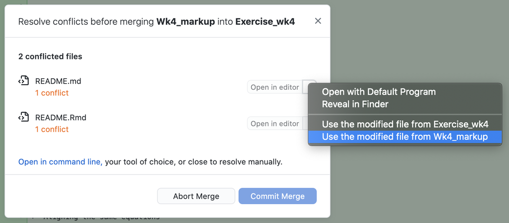

After that, we can stage the changes and commit them in the `Exercise_wk4` branch:

```
% git add -A
% git commit -m 'conflict resolved'
```

# 12 Hand in your exercise

1. Take the merged `Exercise_wk4` branch as your point of departure
2. Create a new branch named `Wk4_yourname`
3. Change the filename of the text file to `yourname.txt`
4. Stage the changes
5. Commit the changes with a custom message
6. Publish your branch on GitHub
7. Do a pull request that can be automatically merged.
8. Post an issue in this year’s Repo, wherin you reference your PR to last year’s repo.

# 13 Solution

```
% git branch Wk4_gerkovink
% git checkout Wk4_gerkovink
Switched to branch 'Wk4_gerkovink'
% mv add_text_file.txt gerkovink.txt
% git add -A
% git commit -m 'gerko`s commit'
[Wk4_gerkovink fb26e75] gerko`s commit
 1 file changed, 0 insertions(+), 0 deletions(-)
 rename add_text_file.txt => gerkovink.txt (100%)
% git push origin Wk4_gerkovink
Enumerating objects: 15, done.
Counting objects: 100% (15/15), done.
Delta compression using up to 8 threads
Compressing objects: 100% (10/10), done.
Writing objects: 100% (10/10), 1002 bytes | 1002.00 KiB/s, done.
Total 10 (delta 7), reused 0 (delta 0)
remote: Resolving deltas: 100% (7/7), completed with 3 local objects.
remote:
remote: Create a pull request for 'Wk4_gerkovink' on GitHub by visiting:
remote:      https://github.com/gerkovink/markup2020/pull/new/Wk4_gerkovink
remote:
To https://github.com/gerkovink/markup2020.git
 * [new branch]      Wk4_gerkovink -> Wk4_gerkovink
```